# Obesity

# 1 Description of DataSchema variable

The description of harmonised variable is the following:

- Short name: `obesity`
- Variable label: `Precense of obesity based in Body Mass Index classification according to the WHO BMI classification (http://apps.who.int/bmi/index.jsp?introPage=intro_3.html): BMI value equal to or above 30Kg/m^2.`
- Variable description: `the BMI variable should be created by dividing weight and hiegh variables by means of the following equation= weight (kg)/height(m)^2. Then, the Obesity variable should be generated according to the WHO cutoff point for BMI classification.`
- Domain: `Physical measures`
- Value type: `Categorical`
- Category coding:

| **Code** | **Category Label** |
| --- | --- |
| 0 | Not obese |
| 1 | Obese |

- Category missings:

| **Code** | **Category Label** |
| --- | --- |
| 991 | CAPI/interviewer error |
| 992 | Impute |
| 993 | Disable to measure |
| 994 | Not attempt/not done |
| 995 | Does not answer |
| 996 | Not applicable |
| 997 | Refuse |
| 998 | Do not know |
| 999 | Missing |

# 2 Data process

## 2.1 England

### 2.1.1 Wave 1

There is no variable.

### 2.1.2 Wave 2

#### 2.1.2.1 Study-specific variable description

The study-specific variables elected to be harmonised are:

- Name: `bmival`
- Label: `(D) Valid BMI - inc estimated>130kg`
- Type of variable: `countinous`
- Missings
  - `-1 = Not Applicable`

```
## $summary
##    Min. 1st Qu.  Median    Mean 3rd Qu.    Max.
##   14.87   24.67   27.28   27.93   30.56   56.15
##
## $values_table
##            No-missings     -1 NA
## Frequency      7225.00 441.00  0
## Percentage       94.25   5.75  0
##
## $n_table
##      Sample size Missing values
## [1,]        7666            441
```

[figure not shown]

#### 2.1.2.2 Harmonisation algorithm

To compute the harmonize variable from the study-specific variable it has to be recoded as follows:

- `BMI<30 into 0`
- `BMI>=30 into 1`
- `recode -1 "Not Applicable" into 996`
- `NA into 999`

**R script:**

```r
ELSA_ds_w2 <- tibble(id = ELSA_bmi$id)
ELSA_ds_w2$obesity <- car::recode(ELSA_bmi[[2]], "0:29.9999999=0; 30:900=1; -1=996; NA=999")
ELSA_ds_w2$obesity <- labelled(ELSA_ds_w2[[2]], labels = c(`not obese` = 0,
    obese = 1, Missing = 999, `Do not know` = 998, Refuse = 997, `Not applicable` = 996,
    `Does not answer` = 995, `Not attempt not done` = 994, `Disable to measure` = 993,
    Impute = 992, `CAPI interviewer error` = 991))
```

#### 2.1.2.3 Statistical description of the new harmonised variable

```
## $values_table
##                  0       1
## Frequency  5139.00 2086.00
## Percentage   67.04   27.21
##
## $missing_values_table
##            991 992 993 994 995    996 997 998 999 NA
## Frequency    0   0   0   0   0 441.00   0   0   0  0
## Percentage   0   0   0   0   0   5.75   0   0   0  0
##
## $n_table
##      Sample size Missing values
## [1,]        7666            441
```

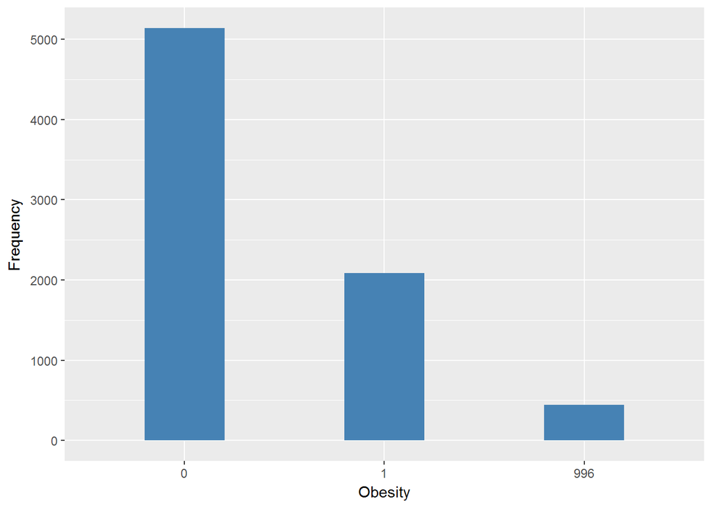

#### 2.1.2.4 Validation

[output not shown]

### 2.1.3 Wave 3

There is no variable.

### 2.1.4 Wave 4

#### 2.1.4.1 Study-specific variable description

- Name: `bmival`
- Label: `(D) Valid BMI - inc estimated>130kg`
- Type of variable: `countinous`
- Missings
  - `-1 = Not Applicable`

```
## $summary
##    Min. 1st Qu.  Median    Mean 3rd Qu.    Max.
##   14.70   24.70   27.50   28.27   31.00   71.10
##
## $values_table
##            No-missings     -1 NA
## Frequency      8262.00 381.00  0
## Percentage       95.59   4.41  0
##
## $n_table
##      Sample size Missing values
## [1,]        8643            381
```

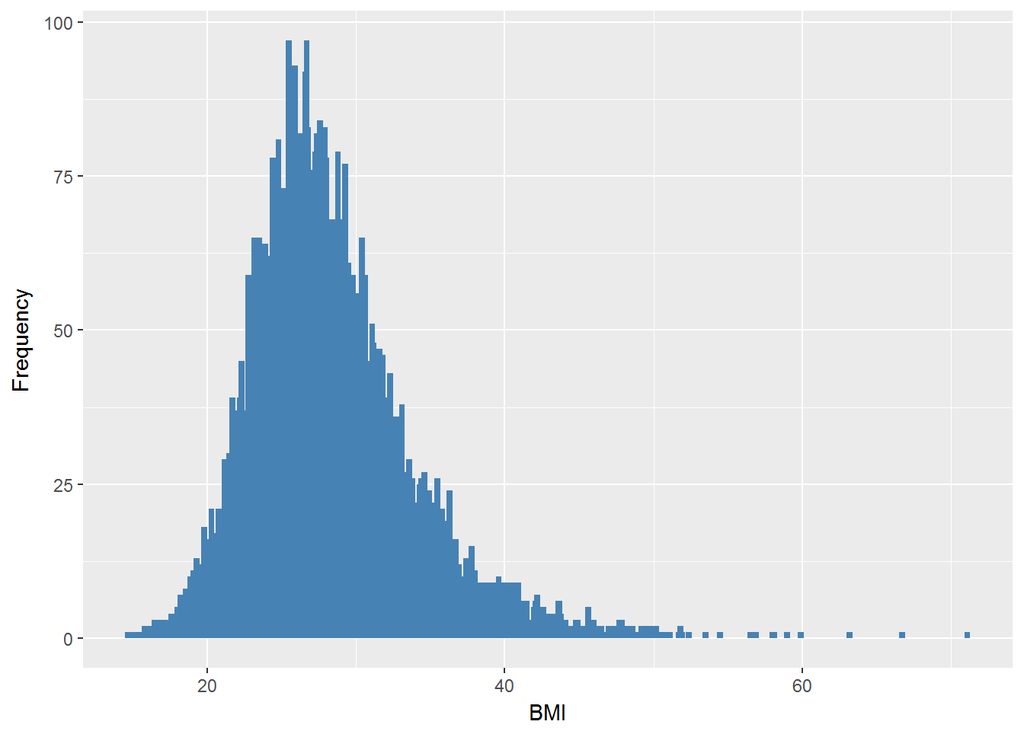

#### 2.1.4.2 Harmonisation algorithm

To compute the harmonize variable from the study-specific variable it has to be recoded as follows:

- `BMI<30 into 0`
- `BMI>=30 into 1`
- `recode -1 "Not Applicable" into 996`
- `NA into 999`

```r
ELSA_ds_w4 <- tibble(id = ELSA_bmi$id)
ELSA_ds_w4$obesity <- car::recode(ELSA_bmi[[2]], "0:29.9999999=0; 30:900=1; -1=996; NA=999")
ELSA_ds_w4$obesity <- labelled(ELSA_ds_w4[[2]], labels = c(`not obese` = 0,
    obese = 1, Missing = 999, `Do not know` = 998, Refuse = 997, `Not applicable` = 996,
    `Does not answer` = 995, `Not attempt not done` = 994, `Disable to measure` = 993,
    Impute = 992, `CAPI interviewer error` = 991))
```

#### 2.1.4.3 Statistical description of the new harmonised variable

```
## $values_table
##                  0       1
## Frequency  5677.00 2585.00
## Percentage   65.68   29.91
##
## $missing_values_table
##            991 992 993 994 995    996 997 998 999 NA
## Frequency    0   0   0   0   0 381.00   0   0   0  0
## Percentage   0   0   0   0   0   4.41   0   0   0  0
##
## $n_table
##      Sample size Missing values
## [1,]        8643            381
```

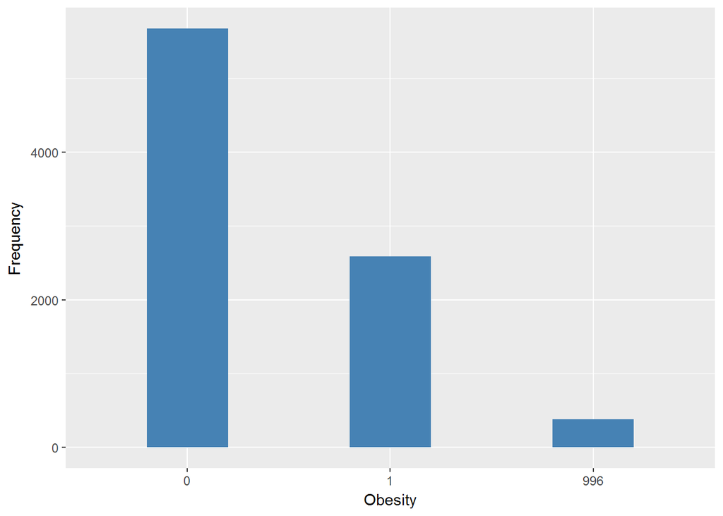

#### 2.1.4.4 Validation

[output not shown]

### 2.1.5 Wave 5

There is no variable.

### 2.1.6 Wave 6

#### 2.1.6.1 Study-specific variable description

The study-specific variable elected to be harmonised is:

- Name: `BMIVAL`
- Label: `(D) Valid BMI - inc estimated>130kg`
- Type of variable: `countinous`
- Missings
  - `-1 = Not Applicable`

```
## $summary
##    Min. 1st Qu.  Median    Mean 3rd Qu.    Max.
##   15.10   24.70   27.50   28.29   31.00   59.40
##
## $values_table
##            No-missings     -1 NA
## Frequency      7693.00 361.00  0
## Percentage       95.52   4.48  0
##
## $n_table
##      Sample size Missing values
## [1,]        8054            361
```

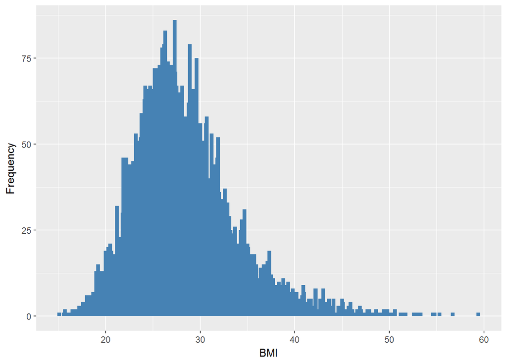

#### 2.1.6.2 Harmonisation algorithm

To compute the harmonize variable from the study-specific variable it has to be recoded as follows:

- `BMI<30 into 0`
- `BMI>=30 into 1`
- `recode -1 "Not Applicable" into 996`
- `NA into 999`

```r
ELSA_ds_w6 <- tibble(id = ELSA_bmi$id)
ELSA_ds_w6$obesity <- car::recode(ELSA_bmi[[2]], "0:29.9999999=0; 30:900=1; -1=996; NA=999")
ELSA_ds_w6$obesity <- labelled(ELSA_ds_w6[[2]], labels = c(`not obese` = 0,
    obese = 1, Missing = 999, `Do not know` = 998, Refuse = 997, `Not applicable` = 996,
    `Does not answer` = 995, `Not attempt not done` = 994, `Disable to measure` = 993,
    Impute = 992, `CAPI interviewer error` = 991))
```

#### 2.1.6.3 Statistical description of the new harmonised variable

```
## $values_table
##                  0       1
## Frequency  5263.00 2430.00
## Percentage   65.35   30.17
##
## $missing_values_table
##            991 992 993 994 995    996 997 998 999 NA
## Frequency    0   0   0   0   0 361.00   0   0   0  0
## Percentage   0   0   0   0   0   4.48   0   0   0  0
##
## $n_table
##      Sample size Missing values
## [1,]        8054            361
```

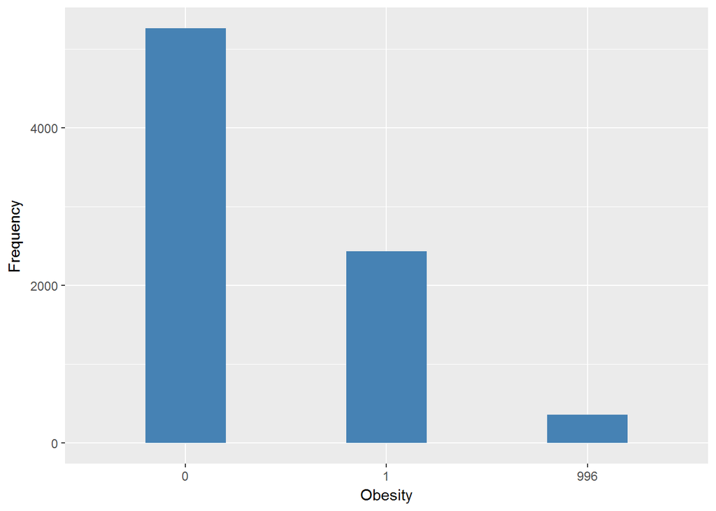

#### 2.1.6.4 Validation

[output not shown]

### 2.1.7 Wave 7

Not found.

## 2.2 Descriptive statistics of the harmonised variable accross populations and waves

Percentages of categories in each harmonised variable by cohort and wave:

```r
# Table HRS
t.hds <- frq(l.hds[[2]][2])[[1]][, c(1, 2)]
for (i in 1:length(l.hds)) {
    t.hds[2 + i] <- frq(l.hds[[i]][2])[[1]][, 4]
}
t.hds[13, ] <- c("n", "sample size", length(l.hds[[1]][[2]]), length(l.hds[[2]][[2]]),
    length(l.hds[[3]][[2]]))
names(t.hds) <- c("val", "label", "Wave2", "Wave4", "Wave6")
kable(t.hds)
```

| val | label | Wave2 | Wave4 | Wave6 |
| --- | --- | --- | --- | --- |
| 0 | not obese | 67.04 | 65.68 | 65.35 |
| 1 | obese | 27.21 | 29.91 | 30.17 |
| 991 | CAPI interviewer error | 0 | 0 | 0 |
| 992 | Impute | 0 | 0 | 0 |
| 993 | Disable to measure | 0 | 0 | 0 |
| 994 | Not attempt not done | 0 | 0 | 0 |
| 995 | Does not answer | 0 | 0 | 0 |
| 996 | Not applicable | 5.75 | 4.41 | 4.48 |
| 997 | Refuse | 0 | 0 | 0 |
| 998 | Do not know | 0 | 0 | 0 |
| 999 | Missing | 0 | 0 | 0 |
| NA | NA | 0 | 0 | 0 |
| n | sample size | 7666 | 8643 | 8054 |

# 3 Quality estimation